# Zaawansowane Modele Liniowe 3

Błażej Wiórek

4/21/2020

## Zadanie 1

Jedynym poleceniem zadania jest pobranie danych więc raport rozpoczyna się od zadania 2.

## Zadanie 2

Wstępny przegląd zbioru danych:

```
## Rows: 1,456
## Columns: 5
## $ X          <int> 1, 2, 3, 4, 5, 6, 7, 8, 9, 10, 11, 12, 13, 14, 15, 16, 17,…
## $ hour       <int> 8, 9, 10, 11, 12, 13, 14, 15, 16, 17, 18, 19, 20, 21, 22, …
## $ day        <fct> Monday, Monday, Monday, Monday, Monday, Monday, Monday, Mo…
## $ events     <int> 0, 0, 0, 0, 0, 0, 0, 0, 0, 0, 0, 0, 0, 0, 0, 0, 0, 0, 0, 0…
## $ no.klients <int> 26, 37, 36, 32, 13, 22, 23, 22, 57, 53, 55, 57, 29, 29, 35…
```

Na potrzeby kolejnych zadań przeprowadzone zostało zrzutowanie predytkorów na typ ‘factor’. Tam gdzie było to możliwe zdefiniowany został porządek na otrzymanych zmiennych kategorycznych.

```
## Rows: 1,456
## Columns: 5
## $ hour       <int> 8, 9, 10, 11, 12, 13, 14, 15, 16, 17, 18, 19, 20, 21, 22, …
## $ day        <ord> Monday, Monday, Monday, Monday, Monday, Monday, Monday, Mo…
## $ events     <ord> 0, 0, 0, 0, 0, 0, 0, 0, 0, 0, 0, 0, 0, 0, 0, 0, 0, 0, 0, 0…
## $ no.klients <int> 26, 37, 36, 32, 13, 22, 23, 22, 57, 53, 55, 57, 29, 29, 35…
## $ hour_fct   <ord> 8, 9, 10, 11, 12, 13, 14, 15, 16, 17, 18, 19, 20, 21, 22, …
```

Pierwszą rzeczą którą można zaobserwować na wykresie poniżej jest różnica w liczbie klientów pomiędzy dniami roboczymi a weekendem. Mniej oczywistą cechą jest to, że wariancja liczby klientów w dniach roboczych jest większa. Odpowiada to założeniom modelu Poissona jako, że dla $X \sim Poi(\lambda)$ zachodzi $E[X]= Var[X] = \lambda$ a więc wariancja rośnie wraz ze średnią. Można wysnuć hipoteze, że zamiast rozpatrywania każdego dnia tygodnia osobno, warto rozróżniać dni tygodnia tylko na podstawie tego czy są to dni robocze czy weekend. Realizacja tego pomysłu stanowi treść zadania 4.

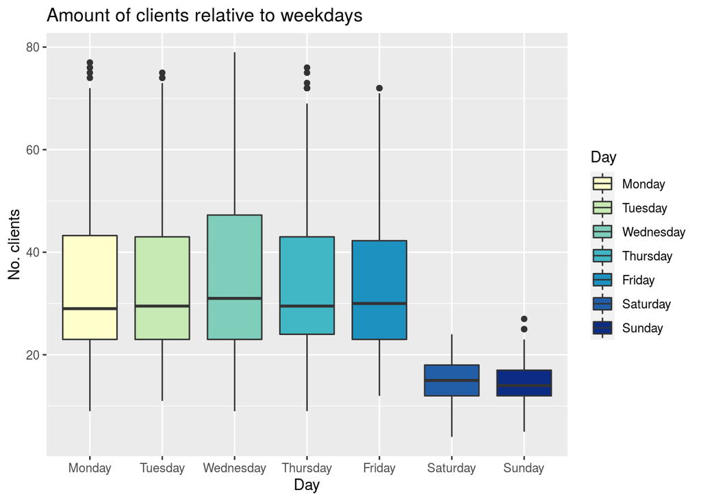

W przeciwieństwie do dni tygodnia wygląda na to, że obecność wydarzeń sportowych danego dnia nie ma wpływu na liczbę klientów.

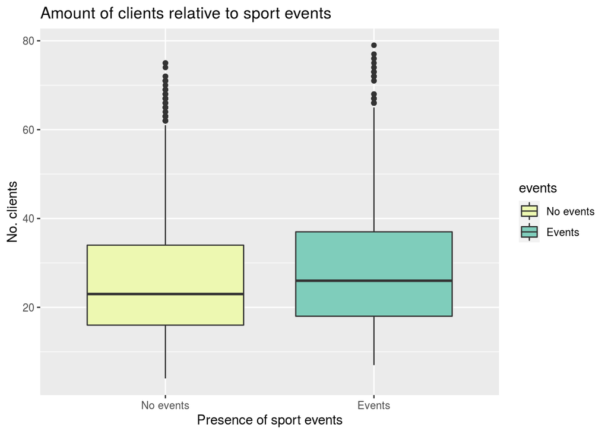

Kolejny wykres przedstawia rozkład klientów w poszczególych godzinach pracy sklepu. Ze zrozumiałych powodów pora dnia istotnie różnicuje liczbę klientów w sklepie. Jest to kolejny wykres sugerujący, że można wprowadzić grupowanie. Jednym z pomysłów na realizacje tego zadania jest podział ze względu na godzinny poranne [8, 11], godziny popołudniowe [12, 15], godziny wieczorne [16, 19] oraz godziny nocne [20, 23]. Przedstawione grupowanie zostało wprowadzone w zadaniu 4.

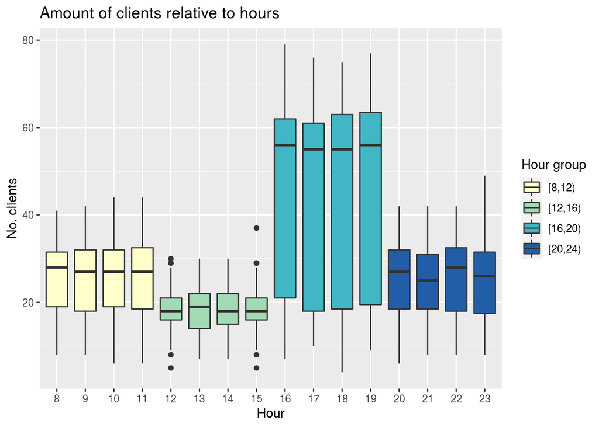

Można się zastanowić czy nie mam tutaj do czynienia ze zjawiskiem nadmiernej dyspersji szczególnie w kontekście liczby klientów pomiędzy godziną 16 a 19. Na podstawie średniej i wariancji (obliczone niżej) można wnioskować, że faktycznie wspomniany problem pojawia się w przypadku tego zbioru danych. Na chwile obecną nie podjęte zostaną żadne kroki mające na celu rozwiązanie tego problemu jako, że problem ten stanowi treść kolejnego raportu.

```
## [1] "Mean:  46.8489 , Std:  456.1507"
```

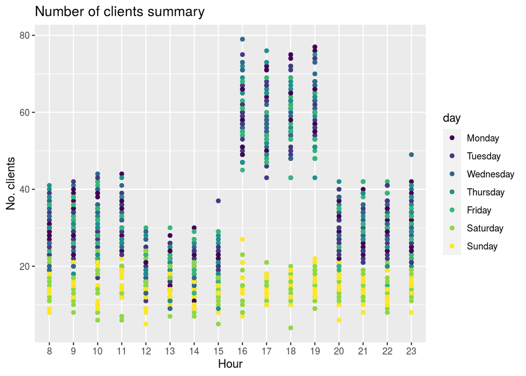

## Zadanie 3

w zadaniu mowa jest o tym, że wszystkie zmienne objaśniające mają być zakodowane jako zmienna kategoryczna. Warto sie więc upewnić, że dane spełniają to założenie.

```
## Rows: 1,456
## Columns: 4
## $ day        <ord> Monday, Monday, Monday, Monday, Monday, Monday, Monday, Mo…
## $ events     <ord> 0, 0, 0, 0, 0, 0, 0, 0, 0, 0, 0, 0, 0, 0, 0, 0, 0, 0, 0, 0…
## $ no.klients <int> 26, 37, 36, 32, 13, 22, 23, 22, 57, 53, 55, 57, 29, 29, 35…
## $ hour_fct   <ord> 8, 9, 10, 11, 12, 13, 14, 15, 16, 17, 18, 19, 20, 21, 22, …
```

Zadanie polega na sprawdzeniu co się stanie w przypadku próby estymowania liczby klientów na podstawie predyktorów kategorycznych uwzględniając wszystkie interakcje pomiędzy poszczególnymi poziomami. Wprowadzone interakcje mają postać indykatorów przy czym regresja polega na uwzględnienie wpływu godziny, dnia tygodnia i wydarzenia sportowego na liczbe klientów. Wprowadzenie wszystkich żądanych interakcji powoduje znaczny wzrost liczby parametrów modelu. Aby obliczyć liczbę nowych współczynników należy określić liczbę poziomów poszczególnych predyktorów:

|  | day | events | hour_fct |
| --- | --- | --- | --- |
| No. levels | 7 | 2 | 16 |

Na podstawie tej informacji wiem, że należy się spodziewać $7*2*16 = 224$ parametrów modelu, co znajduje swoje potwierdzenie we fragmencie kodu zamieszczonego ponżej.

```
## [1] "Amount of model parameters:  224"
```

W analogiczny sposób można określić liczbę parametrów związanych z obecnością wydarzenia sportowego tzn. jeśli wiem, że wszystkich parametrów jest 224 a zmienna events ma 2 poziomy, wystarczy wziąć $\frac{224}{2} = 112$. Równoważnie w sposób automatyczny:

```
## [1] "Events interaction terms:  112"
```

Kolejne pytanie dotyczy istotności wydarzenia sportowego dla modelu.

|  | Estimate | Std. Error | z value | Pr(>\|z\|) |
| --- | --- | --- | --- | --- |
| Sport events coef. | -0.0055 | 0.0082 | -0.6659 | 0.5055 |

Z powyższego podsumowania wnioskuje, że włączenie wydarzenia sportowego nie jest konieczne (brak podstaw do odrzucenia $H_0: \beta_{events} = 0$).

Ostatnie pytanie dotyczy istotności interakcji związanych z wydarzeniem sportowym. Aby odpowiedzieć na to pytanie zlicze te współczynniki dla których p-wartość jest mniejsza niż standardowy poziom istotności $\alpha = 0.05$.

```
## [1] "Irrelevant predictors at 0.05:  7"
```

Spośród 112 współczynników związanych z wydarzeniem sportowym i zaledwie w 7 przypadkach hipoteza zerowa testu istotności została odrzucona. Można się spodziewać, że otrzymana liczba to błąd losowy związany z mocą testu.

Przedstawione wnioskowanie sugeruje, że można pozbyć się predyktora związanego z wydarzeniami sportowymi z modelu. Podstawową zaletą takiego posunięcia jest zmniejszenie liczby parametrów modelu. Aby w jakiś sposób potwierdzić ten wniosek przedstawione zostało porównanie modelu z wykorzystaniem events oraz po usunięciu events ze zbioru predyktorów.

|  | Full model | Reduced model |
| --- | --- | --- |
| No. parameters | 224.000 | 112.000 |
| AIC | 9185.503 | 9077.638 |
| BIC | 10368.996 | 9669.384 |
| Df | 1232.000 | 1344.000 |

Współczynniki dopasowania modelu AIC oraz BIC są mniejsze dla modelu bez predyktora events. Dodatkowo liczba parametrów modelu zmiejszyła się o połowę.

## Zadanie 4

Kolejny krok w kierunku zmniejszenia liczby parametrów modelu został zaproponowany przy wstępnej analizie wykresów. Polega on na łączeniu poziomów predyktorów, które charakteryzują się podobnym wpływem na liczbę klientów. Realizacja tego pomysłu polega na zgrupowaniu godzin w bloki czterogodzinne oraz wykorzystaniu indyktatora mówiącego czy dany dzień jest dniem wolnym czy też roboczym, zamiast poszczególnych dni tygodnia osobno.

Liczba współczynników modelu uzyskanego w wyniku zastosowania przedstawionych kroków wynosi:

```
## [1] "Number of coefficients:  8"
```

Jako, że model nie jest zagnieżdżony w modelu zawierającym wszystkie interakcje (Zadanie 3), skorzystam z AIC i BIC do porównania modeli.

|  | Full model | Reduced model |
| --- | --- | --- |
| No. parameters | 224.000 | 8.000 |
| AIC | 9185.503 | 8946.356 |
| BIC | 10368.996 | 8988.623 |
| Df | 1232.000 | 1448.000 |

Wartości AIC oraz BIC sugerują, że jest to najlepszy z modeli uzyskanych do tej pory. Dodatkowo warto zwrócić uwage, ze zawiera on zaledwie 8 współczynników.

## Zadanie 5

**Treść zadania**: Stwórz tabelę otrzymaną w oparciu o model z zadania 4 składającą się z czterech wierszy. W pierwszym wierszu zamieść informację o wszystkich podgrupach, do których trafiają poszczególne godziny w róznych dniach tygodnia, np. dzień roboczy 8:00- 11:59; dzien weekendowy 16:00-19:59 itd. W drugim wierszu zamieść średnią liczbę obsłużonych klientów (na godzinę) odpowiadającą podgrupie z pierwszego wiersza. W trzecim i czwartym wierszu wpisz postac predyktora liniowego $\eta_i = x_{i,1}\hat{\beta_1} + ... + x_{i, p-1}\hat{\beta}_{p-1}$ oraz jego wartość odpowiadającego podgrupie z pierwszego wiersza.

Na potrzeby czytelności przedstawionego rozwiązania stransponowałem macierz o której mowa w zadaniu.

| Hour group | No. clients | Predictors | Coef. value |
| --- | --- | --- | --- |
| workday_[8,12) | 390.100 | (Intercept) + is_workday1 | 3.4015 |
| workday_[12,16) | 256.250 | (Intercept) + hour_blocks[12,16) + is_workday1 + hour_blocks[12,16):is_workday1 | 2.9812 |
| workday_[16,20) | 775.350 | (Intercept) + hour_blocks[16,20) + is_workday1 + hour_blocks[16,20):is_workday1 | 4.0884 |
| workday_[20,24) | 389.750 | (Intercept) + hour_blocks[20,24) + is_workday1 + hour_blocks[20,24):is_workday1 | 3.4006 |
| weekend_[8,12) | 192.250 | (Intercept) | 2.6938 |
| weekend_[12,16) | 194.375 | (Intercept) + hour_blocks[12,16) | 2.7048 |
| weekend_[16,20) | 193.250 | (Intercept) + hour_blocks[16,20) | 2.6990 |
| weekend_[20,24) | 186.875 | (Intercept) + hour_blocks[20,24) | 2.6655 |

Należy zwrócić uwagę na to, że zgodnie z oczekiwaniami współczynniki odpowiadające sobocie i niedzieli są porównywalne. W przypadku dni roboczych obserwowana jest większa wariancja. Istotna uwaga jest taka, że jako baseline przyjęta została wartość odpowiadająca weekendowi w godzinach porannych ([8, 12)).

## Zadanie 6

Celem zadania jest sprawdzenie czy predyktory liniowe odpowiadające podgrupom godzin weekendowych są takie same. Na podstawie podsumowania dla wykorzystanego modelu można zaobserwować, że baseline (Intercept) jest istotny, jednak poszczególne wartości godzinowe dla weekendów nie są istotne.

```
##
## Call:
## glm(formula = no.klients ~ hour_blocks * is_workday, family = "poisson",
##     data = shop_data.extended)
##
## Deviance Residuals:
##     Min       1Q   Median       3Q      Max
## -3.7441  -0.7441  -0.0014   0.7185   3.4673
##
## Coefficients:
##                                 Estimate Std. Error z value Pr(>|z|)
## (Intercept)                     2.693847   0.025499 105.646   <2e-16 ***
## hour_blocks[12,16)              0.010993   0.035962   0.306    0.760
## hour_blocks[16,20)              0.005188   0.036014   0.144    0.885
## hour_blocks[20,24)             -0.028357   0.036319  -0.781    0.435
## is_workday1                     0.707607   0.027899  25.363   <2e-16 ***
## hour_blocks[12,16):is_workday1 -0.431242   0.040207 -10.726   <2e-16 ***
## hour_blocks[16,20):is_workday1  0.681723   0.038596  17.663   <2e-16 ***
## hour_blocks[20,24):is_workday1  0.027459   0.039693   0.692    0.489
## ---
## Signif. codes:  0 '***' 0.001 '**' 0.01 '*' 0.05 '.' 0.1 ' ' 1
##
## (Dispersion parameter for poisson family taken to be 1)
##
##     Null deviance: 12434.9  on 1455  degrees of freedom
## Residual deviance:  1552.5  on 1448  degrees of freedom
## AIC: 8946.4
##
## Number of Fisher Scoring iterations: 4
```

Formalnie sprawdzenie wymaga przeprowadzenia testu Walda. Interesujące mnie współczynniki to: $\eta_0 = \beta_0$, $\eta_1 = \beta_0 + \beta_1$, $\eta_2 = \beta_0 + \beta_2$, $\eta_3 = \beta_0 + \beta_3$. Należy przetestować $H_0: \eta_0 = \eta_1 = \eta_2 = \eta_3$ za pomocą testu Walda.

Macierz $L$ związaną z takim testem można przedstawić jako:

```
##      [,1] [,2] [,3] [,4] [,5] [,6] [,7] [,8]
## [1,]    0    1    0    0    0    0    0    0
## [2,]    0    0    1    0    0    0    0    0
## [3,]    0    0    0    1    0    0    0    0
```

Co jest równoważne testowaniu $\beta_1 = 0$, $\beta_2 = 0$, $\beta_3 = 0$.

```
## [1] "P-value for Wald test:  0.8471"
```

Nie ma zatem podstaw do odrzucenia hipotezy $H_0$.

## Zadanie 7

**Treść zadania**: Właściciel sklepu poprosił, abyś na podstawie wyników tabeli zaplanował optymalną liczbę pracowników oraz grafik pracy. W tym celu załóż że w ciągu godziny jeden pracownik jest w stanie obsłużyć do 20 klientów.

Aby zaproponować grafik konieczne jest wyestymowanie liczby klientów w poszczególnych blokach godzinowych uwzględniając podział na dni robocze i weekendy.

| Workday | Hour block | Predicted no. clients | Clients per worker |
| --- | --- | --- | --- |
| 0 | [8,12) | 14.7885 | 1 |
| 0 | [12,16) | 14.9519 | 1 |
| 0 | [16,20) | 14.8654 | 1 |
| 0 | [20,24) | 14.3750 | 1 |
| 1 | [8,12) | 30.0077 | 2 |
| 1 | [12,16) | 19.7115 | 1 |
| 1 | [16,20) | 59.6423 | 3 |
| 1 | [20,24) | 29.9808 | 2 |

Jeśli założyć, że pracownik nie może pracować więcej niż 8h dziennie to można zaproponować następujący grafik:

| Workday | Hour block | Schedule |
| --- | --- | --- |
| 0 | [8,12) | P1 |
| 0 | [12,16) | P1 |
| 0 | [16,20) | P2 |
| 0 | [20,24) | P2 |
| 1 | [8,12) | P1 + P2 |
| 1 | [12,16) | P2 |
| 1 | [16,20) | P1 + P3 + P4 |
| 1 | [20,24) | P3 + P4 |

Oznaczenie $P_i$ to okreslenie i-tego pracownika. Mam zatem dwie zmiany weekendowe - poranną [8, 16) i nocną [16, 24) oraz nieco bardziej skomplikowany układ pracowników w czasie tygodnia. Jeśli przyjąć ustawienie takie jak przedstawione i po prostu zidentyfikować każde $Pi$ z jedną osobą to każdy pracownik mieściłby się w limicie 8h dziennie ale musiałby pracować 56h tygodniowo w przypadku $P1$ i $P2$ oraz 40h tygodniowo w przypadku $P3$, $P4$. Aby rozwiązać ten problem można wprowadzić następujący grafik tygodniowy:

|  | Monday | Tuesday | Wednesday | Thursday | Friday | Saturday | Sunday |
| --- | --- | --- | --- | --- | --- | --- | --- |
| [8,12) | P1 + P2 | P1 + P2 | P5 + P6 | P5 + P6 | P5 + P6 | P1 | P1 |
| [12,16) | P2 | P2 | P6 | P6 | P6 | P2 | P2 |
| [16,20) | P1 + P3 + P4 | P1 + P3 + P4 | P5 + P7 + P8 | P5 + P7 + P8 | P5 + P7 + P8 | P3 | P3 |
| [20,24) | P3 + P4 | P3 + P4 | P7 + P8 | P7 + P8 | P7 + P8 | P4 | P4 |